# Code Through Assignment

Zeina Zeineddine

# **data.table Package**

## *Introduction*

This Code Through is here to introduce a package that is much useful when working with large data and mainly tabular data in R. This package is the **data.table**. The data.table is so popular because of its speed of execution on large data. In general we can say that this package is:

> A package designed for working with heavy duty data wrangling.

## *Loading data.table*

```r
library('data.table')
```

## *Importing data*

Within this Code Through, we will work on the **iris** data set that is built in R.

```r
library(DT)
datatable(iris)
```

|  | Sepal.Length | Sepal.Width | Petal.Length | Petal.Width | Species |
| --- | --- | --- | --- | --- | --- |
| 1 | 5.1 | 3.5 | 1.4 | 0.2 | setosa |
| 2 | 4.9 | 3 | 1.4 | 0.2 | setosa |
| 3 | 4.7 | 3.2 | 1.3 | 0.2 | setosa |
| 4 | 4.6 | 3.1 | 1.5 | 0.2 | setosa |
| 5 | 5 | 3.6 | 1.4 | 0.2 | setosa |
| 6 | 5.4 | 3.9 | 1.7 | 0.4 | setosa |
| 7 | 4.6 | 3.4 | 1.4 | 0.3 | setosa |
| 8 | 5 | 3.4 | 1.5 | 0.2 | setosa |
| 9 | 4.4 | 2.9 | 1.4 | 0.2 | setosa |
| 10 | 4.9 | 3.1 | 1.5 | 0.1 | setosa |

[output cut: 140 more lines]

## *Data Table Syntax*

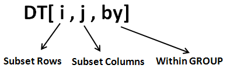

Data Table Syntax

## *Some Special Features*

Column Filters  
In addition to the general global search filter appearing on the top-right of the table, We can add a filter argument in datatable() to be able to do more specific column filters.

```r
datatable(iris, filter = 'top', options = list(
  pageLength = 5, autoWidth = TRUE
))
```

|  | Sepal.Length | Sepal.Width | Petal.Length | Petal.Width | Species |
| --- | --- | --- | --- | --- | --- |
| 1 | 5.1 | 3.5 | 1.4 | 0.2 | setosa |
| 2 | 4.9 | 3 | 1.4 | 0.2 | setosa |
| 3 | 4.7 | 3.2 | 1.3 | 0.2 | setosa |
| 4 | 4.6 | 3.1 | 1.5 | 0.2 | setosa |
| 5 | 5 | 3.6 | 1.4 | 0.2 | setosa |
| 6 | 5.4 | 3.9 | 1.7 | 0.4 | setosa |
| 7 | 4.6 | 3.4 | 1.4 | 0.3 | setosa |
| 8 | 5 | 3.4 | 1.5 | 0.2 | setosa |
| 9 | 4.4 | 2.9 | 1.4 | 0.2 | setosa |
| 10 | 4.9 | 3.1 | 1.5 | 0.1 | setosa |

[output cut: 140 more lines]

Selecting a given set of columns  
When doing data analysis we need to select some specific columns to work with the data we need. For example if we want to select the columns titled only as Sepal Width and Petal Width, we do the following:

```r
library(data.table)
myVector <- c('Sepal.Width','Petal.Width')
myVector
```

```
## [1] "Sepal.Width" "Petal.Width"
```

```r
irisDT <- data.table(iris)
irisDT[, ..myVector]
```

```
##      Sepal.Width Petal.Width
##   1:         3.5         0.2
##   2:         3.0         0.2
##   3:         3.2         0.2
##   4:         3.1         0.2
##   5:         3.6         0.2
##  ---
## 146:         3.0         2.3
## 147:         2.5         1.9
## 148:         3.0         2.0
## 149:         3.4         2.3
## 150:         3.0         1.8
```

## *Grouping*

1-How can we get the mean Petal Length for each Species?

Grouping is used to solve this and it can be done using the by argument. We will use the by argument to get the mean petal length for each species of the 3 types of Iris flowers under study.

```r
# Mean Petal Length by Species

irisDT[, .(mean_Petal.Length=mean(Petal.Length)), by=Species]
```

```
##       Species mean_Petal.Length
## 1:     setosa             1.462
## 2: versicolor             4.260
## 3:  virginica             5.552
```

So the Setosa have a mean petal length of 1.46, the Versicolor has a mean Petal length od 4.2 and the Virginica has a mean Petal length of 5.552.

2- How can we know the Total number of setosa flowers we have?

```r
 irisDT[Species=="setosa", .N, by =Species]
```

```
##    Species  N
## 1:  setosa 50
```

So we have a total number of 50 Setosa flowers.

3- How can we know the average sepal length and average petal length of a setosa flower?

```r
irisDT[Species == "setosa",
        .(mean(Sepal.Length), mean(Petal.Length)),
        by = .(Species)]
```

```
##    Species    V1    V2
## 1:  setosa 5.006 1.462
```

Since we did not provide column names for the expressions in j, they were automatically generated as V1 and V2.

## *Chaining*

Chaining is so useful when doing data manipulation. With chaining we can do multiple data.table operations without having to store intermediate results. so with chaining we will reach our output with less written codes.

1– How can we order IRIS data related to the setosa flower using the column Sepal Length in descending order?

```r
irisDT[Species == "setosa", .N, by = .(Sepal.Length)][order(-Sepal.Length)]
```

```
##     Sepal.Length N
##  1:          5.8 1
##  2:          5.7 2
##  3:          5.5 2
##  4:          5.4 5
##  5:          5.3 1
##  6:          5.2 3
##  7:          5.1 8
##  8:          5.0 8
##  9:          4.9 4
## 10:          4.8 5
## 11:          4.7 2
## 12:          4.6 4
## 13:          4.5 1
## 14:          4.4 3
## 15:          4.3 1
```

```r
head(irisDT, 10)
```

```
##     Sepal.Length Sepal.Width Petal.Length Petal.Width Species
##  1:          5.1         3.5          1.4         0.2  setosa
##  2:          4.9         3.0          1.4         0.2  setosa
##  3:          4.7         3.2          1.3         0.2  setosa
##  4:          4.6         3.1          1.5         0.2  setosa
##  5:          5.0         3.6          1.4         0.2  setosa
##  6:          5.4         3.9          1.7         0.4  setosa
##  7:          4.6         3.4          1.4         0.3  setosa
##  8:          5.0         3.4          1.5         0.2  setosa
##  9:          4.4         2.9          1.4         0.2  setosa
## 10:          4.9         3.1          1.5         0.1  setosa
```

We can tack expressions one after another, forming a chain of operations, i.e., DT[ … ][ … ][ … ].

## *.SD and its uses*

The .SD object is a data.table that contains all the columns of the original data.table except the column specified in ‘by’ argument. Here is an example:

```r
irisDT[, .SD, by=Species]
```

```
##        Species Sepal.Length Sepal.Width Petal.Length Petal.Width
##   1:    setosa          5.1         3.5          1.4         0.2
##   2:    setosa          4.9         3.0          1.4         0.2
##   3:    setosa          4.7         3.2          1.3         0.2
##   4:    setosa          4.6         3.1          1.5         0.2
##   5:    setosa          5.0         3.6          1.4         0.2
##  ---
## 146: virginica          6.7         3.0          5.2         2.3
## 147: virginica          6.3         2.5          5.0         1.9
## 148: virginica          6.5         3.0          5.2         2.0
## 149: virginica          6.2         3.4          5.4         2.3
## 150: virginica          5.9         3.0          5.1         1.8
```

```r
# returns the irisDT table grouped by Species
```

Also, we can specify the columns that should be part of .SD using the .SDCols as follows:

```r
output <- irisDT[, lapply(.SD, mean), by=Species, .SDcols=c("Sepal.Length", "Petal.Length")]
output
```

```
##       Species Sepal.Length Petal.Length
## 1:     setosa        5.006        1.462
## 2: versicolor        5.936        4.260
## 3:  virginica        6.588        5.552
```

The output now contains only the specified columns relative to species types..

```r
irisDT[Species == "setosa",         ## Only on setosa flowers
        lapply(.SD, mean),          ## compute the mean
        by = .(Petal.Width),        ## for every petal width
        .SDcols = c("Sepal.Length", "Petal.Length")] ## for just those specified in .SDcols
```

```
##    Petal.Width Sepal.Length Petal.Length
## 1:         0.2     4.972414     1.444828
## 2:         0.4     5.300000     1.571429
## 3:         0.3     4.971429     1.428571
## 4:         0.1     4.820000     1.380000
## 5:         0.5     5.100000     1.700000
## 6:         0.6     5.000000     1.600000
```

## *.N and .I uses*

.N gives the number of rows present.

So the following will give the number of rows for each unique value of Sepal.Width.

```r
irisDT[, .N, by=Sepal.Width]
```

```
##     Sepal.Width  N
##  1:         3.5  6
##  2:         3.0 26
##  3:         3.2 13
##  4:         3.1 11
##  5:         3.6  4
##  6:         3.9  2
##  7:         3.4 12
##  8:         2.9 10
##  9:         3.7  3
## 10:         4.0  1
## 11:         4.4  1
## 12:         3.8  6
## 13:         3.3  6
## 14:         4.1  1
## 15:         4.2  1
## 16:         2.3  4
## 17:         2.8 14
## 18:         2.4  3
## 19:         2.7  9
## 20:         2.0  1
## 21:         2.2  3
## 22:         2.5  8
## 23:         2.6  5
##     Sepal.Width  N
```

```r
# < returns the number of rows for each unique value of Sepal.Width>
```

To create row numbers of items, we use the .I.

Thus, to return the row numbers where Sepal.Width=4 we do the following:

```r
irisDT[, .I[Sepal.Width==4]]
```

```
## [1] 15
```

## *Keys*

Setting one or more keys on a data.table enables it to perform binary search, which is fast when we are dealing with large data. Thus, the filtering operations are so fast after setting the keys. But we should be aware that by setting a key, the `data.table` gets sorted by that key.

1- how can we directly order by our data according to Sepal Width?

```r
irisDT[ Species=="setosa",
        .(mean(Sepal.Length), mean(Petal.Length)),
        keyby = .(Sepal.Width)]
```

```
##     Sepal.Width       V1       V2
##  1:         2.3 4.500000 1.300000
##  2:         2.9 4.400000 1.400000
##  3:         3.0 4.700000 1.366667
##  4:         3.1 4.800000 1.525000
##  5:         3.2 4.680000 1.360000
##  6:         3.3 5.050000 1.550000
##  7:         3.4 5.033333 1.566667
##  8:         3.5 5.150000 1.416667
##  9:         3.6 4.833333 1.266667
## 10:         3.7 5.266667 1.500000
## 11:         3.8 5.250000 1.675000
## 12:         3.9 5.400000 1.500000
## 13:         4.0 5.800000 1.200000
## 14:         4.1 5.200000 1.500000
## 15:         4.2 5.500000 1.400000
## 16:         4.4 5.700000 1.500000
```

So we have got a table of ordered values showing the mean sepal length and mean petal length according to sepal width ordered values.

## *References*

[Refernce 1-MachineLearningPlus](https://www.machinelearningplus.com/data-manipulation/datatable-in-r-complete-guide/)

[Reference 2-Stackoverflow](https://stackoverflow.com/)

[Click Here](https://www.dezyre.com/data-science-in-r-programming-tutorial/r-data-table-tutorial) For additional information and details about the data.table package.